# Implementando un autoencoder variacional

Open In Colab

# Modelos generativos

Ahora, consideremos que no solo queremos aprender la distribución subyacente de los datos para hacer clasificación sobre datos no vistos (evaluar la probabilidad de que una nueva imagen sea o no un digito), sino que queremos generar muestras de (muestrear) dicha distribución. Es decir, queremos generar imágenes que sean muy parecidas a estos digitos, imágenes que no han sido vistas antes en el proceso de entrenamiento. Para esta nuevo problema, los modelos predictivos son útiles para indicar que tan parecida es una imágen a un digito no son necesariamente útiles para sintetizar imágenes de digitos.

Si nuestros datos x (en la base de datos X) se distribuyen de acuerdo a la distribución verdadera P(x), el próposito es ahora, estimar una distribución (z) que podamos muestrear y que sea lo mas similar posible a P(x).

# Dataset MNIST (Generación de imagenes)

El ejemplo que usaremos es el de generar imágenes de dígitos manuscrito a partir de los ejemplos en la BD MNIST.

La idea clave en los autoencoders variacionales es que nuestros datos, aunque sean de muy altas dimensiones (28×28=784 pixeles), en realidad “viven” en un espacio de baja dimensión el cual es parametrizado por el vector z; que, como digimos, es de baja dimensión. Este vector z es la variable latente y codifica la información para generar las imágenes. Variando z generamos los distintos dígitos con sus distintos estilos.

Este dataset puede ser descargado de diversas fuentes incluido keras.

```
Downloading data from https://storage.googleapis.com/tensorflow/tf-keras-datasets/mnist.npz

11490434/11490434 ━━━━━━━━━━━━━━━━━━━━ 2s 0us/step
```

```
Numero de datos para train:  (70000, 28, 28, 1)
```

# Definicion de hiperparametros

En general queremos implementar la siguiente arquitectura:

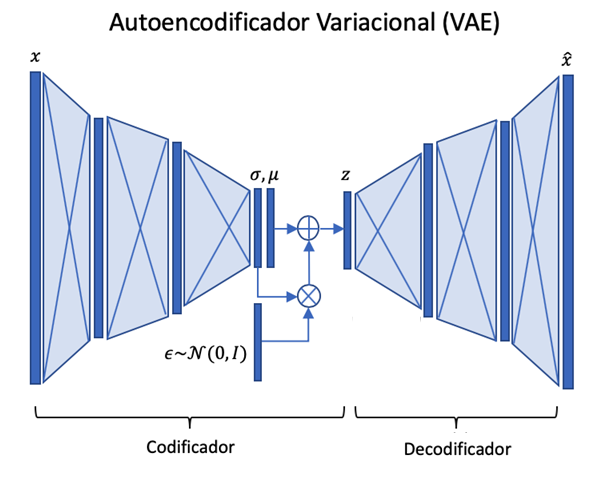

En la figura de arriba se aprecia que el codificador “codifica” $\mathbf{x}$ en $\mathbf{z}$ en una distribución gausiana con los parametros $\mu$ y $\sigma$ y el decodificador “decodifica” $\mathbf{z}$ en $\hat{\mathbf{x}}$ su distribución original. También se aprecia como $\mu(\mathbf{x})$ y $\sigma(\mathbf{x})$ (los parametros de la distribición $\mathbf{p(z)}$ se obtienen mediante una DNN determinística y que $\mathbf{z}$ se obtiene mediante el “truco de la reparametrización”. Cuando la red se entrena en forma completa, tanto la propagación hacia adelante como la retropropagación (para calcular el gradiente) se hace a través de capas determinísticas y continuas sobre los parámetros de $Q_{\theta}(\mathbf{z}|\mathbf{x})$, $P_{\theta}(\mathbf{z})$ y $P_{\theta}(\mathbf{x}|\mathbf{z})$.

## Función de muestreo del espacio latente

Recordemos que p(z) es una distribución y para poder muestrear datos de ella debemos hacerlo usando la técnica de reparametrización que es tomar datos aleatorios de una función normal y luego usar los parámetros $\mu$ y $\sigma$ de p(z) para muestrear datos que siguen la distribución p(z) sin introducir este termino aleatorio a la red. La formula es:

$y = \mu + \sigma \epsilon, \quad \text{donde} \quad \epsilon \sim \mathcal{N}(0, I)$

## Codificador (encoder)

Una vez que tenemos la media y la log-varianzas generamos la muestra para enviarla al decodificador.

```
Model: "encoder"
```

```
┏━━━━━━━━━━━━━━━━━━━━━┳━━━━━━━━━━━━━━━━━━━┳━━━━━━━━━━━━┳━━━━━━━━━━━━━━━━━━━┓
┃ Layer (type)        ┃ Output Shape      ┃    Param # ┃ Connected to      ┃
┡━━━━━━━━━━━━━━━━━━━━━╇━━━━━━━━━━━━━━━━━━━╇━━━━━━━━━━━━╇━━━━━━━━━━━━━━━━━━━┩
│ input_layer         │ (None, 28, 28, 1) │          0 │ -                 │
│ (InputLayer)        │                   │            │                   │
├─────────────────────┼───────────────────┼────────────┼───────────────────┤
│ conv2d (Conv2D)     │ (None, 14, 14,    │        320 │ input_layer[0][0] │
│                     │ 32)               │            │                   │
├─────────────────────┼───────────────────┼────────────┼───────────────────┤
│ conv2d_1 (Conv2D)   │ (None, 7, 7, 64)  │     18,496 │ conv2d[0][0]      │
├─────────────────────┼───────────────────┼────────────┼───────────────────┤
│ flatten (Flatten)   │ (None, 3136)      │          0 │ conv2d_1[0][0]    │
├─────────────────────┼───────────────────┼────────────┼───────────────────┤
│ dense (Dense)       │ (None, 16)        │     50,192 │ flatten[0][0]     │
├─────────────────────┼───────────────────┼────────────┼───────────────────┤
│ z_mean (Dense)      │ (None, 2)         │         34 │ dense[0][0]       │
├─────────────────────┼───────────────────┼────────────┼───────────────────┤
│ z_log_var (Dense)   │ (None, 2)         │         34 │ dense[0][0]       │
├─────────────────────┼───────────────────┼────────────┼───────────────────┤
│ sampling (Sampling) │ (None, 2)         │          0 │ z_mean[0][0],     │
│                     │                   │            │ z_log_var[0][0]   │
└─────────────────────┴───────────────────┴────────────┴───────────────────┘
```

```
 Total params: 69,076 (269.83 KB)
```

```
 Trainable params: 69,076 (269.83 KB)
```

```
 Non-trainable params: 0 (0.00 B)
```

[figure not shown]

## Decodificador (decoder)

```
Model: "decoder"
```

```
┏━━━━━━━━━━━━━━━━━━━━━━━━━━━━━━━━━┳━━━━━━━━━━━━━━━━━━━━━━━━┳━━━━━━━━━━━━━━━┓
┃ Layer (type)                    ┃ Output Shape           ┃       Param # ┃
┡━━━━━━━━━━━━━━━━━━━━━━━━━━━━━━━━━╇━━━━━━━━━━━━━━━━━━━━━━━━╇━━━━━━━━━━━━━━━┩
│ input_layer_1 (InputLayer)      │ (None, 2)              │             0 │
├─────────────────────────────────┼────────────────────────┼───────────────┤
│ dense_1 (Dense)                 │ (None, 3136)           │         9,408 │
├─────────────────────────────────┼────────────────────────┼───────────────┤
│ reshape (Reshape)               │ (None, 7, 7, 64)       │             0 │
├─────────────────────────────────┼────────────────────────┼───────────────┤
│ conv2d_transpose                │ (None, 14, 14, 64)     │        36,928 │
│ (Conv2DTranspose)               │                        │               │
├─────────────────────────────────┼────────────────────────┼───────────────┤
│ conv2d_transpose_1              │ (None, 28, 28, 32)     │        18,464 │
│ (Conv2DTranspose)               │                        │               │
├─────────────────────────────────┼────────────────────────┼───────────────┤
│ conv2d_transpose_2              │ (None, 28, 28, 1)      │           289 │
│ (Conv2DTranspose)               │                        │               │
└─────────────────────────────────┴────────────────────────┴───────────────┘
```

```
 Total params: 65,089 (254.25 KB)
```

```
 Trainable params: 65,089 (254.25 KB)
```

```
 Non-trainable params: 0 (0.00 B)
```

[figure not shown]

# Definición del VAE como un modelo de Keras con un custom train_step

## Función de pérdida para el VAE

Como vimos en la derivación, la función de pérdida usada en autencoders variacionales es una combinación de la entropía cruzada binaria $\mathbb{E}_{z \sim Q} \left\{log P(\mathbf{x} | \mathbf{z}) \right\}$ y la Divergencia de Kullback-Leibler $D\left[ Q(\mathbf{z}|\mathbf{x}) \| P(\mathbf{z}) \right]$.

$D\left[ Q(\mathbf{z}|\mathbf{x}) \| P(\mathbf{z}) \right] = \frac{1}{2} \sum_i \left[ \sigma_{x_i}^{2} + \mu_{x_i}^{2} - 1 - \log \sigma_{x_i}^{2} \right]$

y

$\mathbb{E}_{z \sim Q} \left\{log P(\mathbf{x} | \mathbf{z}) \right\} = \sum_i \left[ x_{i}log(\hat{x_i}) + (1 - x_{i})log(1 - \hat{x_i}) \right]$

```
547/547 ━━━━━━━━━━━━━━━━━━━━ 13s 11ms/step - kl_loss: 2.7686 - logP: 250.3470 - loss: 253.1156


547/547 ━━━━━━━━━━━━━━━━━━━━ 3s 6ms/step - kl_loss: 5.5686 - logP: 171.6053 - loss: 177.1738


547/547 ━━━━━━━━━━━━━━━━━━━━ 3s 6ms/step - kl_loss: 5.8452 - logP: 162.2652 - loss: 168.1104


547/547 ━━━━━━━━━━━━━━━━━━━━ 3s 6ms/step - kl_loss: 6.0985 - logP: 157.5806 - loss: 163.6791


547/547 ━━━━━━━━━━━━━━━━━━━━ 5s 7ms/step - kl_loss: 6.2308 - logP: 154.9196 - loss: 161.1504


547/547 ━━━━━━━━━━━━━━━━━━━━ 3s 6ms/step - kl_loss: 6.2661 - logP: 152.9792 - loss: 159.2452


547/547 ━━━━━━━━━━━━━━━━━━━━ 3s 6ms/step - kl_loss: 6.2872 - logP: 152.4144 - loss: 158.7016


547/547 ━━━━━━━━━━━━━━━━━━━━ 3s 6ms/step - kl_loss: 6.3364 - logP: 150.7463 - loss: 157.0827


547/547 ━━━━━━━━━━━━━━━━━━━━ 4s 7ms/step - kl_loss: 6.3327 - logP: 150.0146 - loss: 156.3473


547/547 ━━━━━━━━━━━━━━━━━━━━ 5s 6ms/step - kl_loss: 6.3740 - logP: 149.2435 - loss: 155.6175


547/547 ━━━━━━━━━━━━━━━━━━━━ 3s 6ms/step - kl_loss: 6.3711 - logP: 148.9789 - loss: 155.3501


547/547 ━━━━━━━━━━━━━━━━━━━━ 4s 7ms/step - kl_loss: 6.3763 - logP: 148.3557 - loss: 154.7320


547/547 ━━━━━━━━━━━━━━━━━━━━ 5s 6ms/step - kl_loss: 6.3920 - logP: 147.2762 - loss: 153.6683


547/547 ━━━━━━━━━━━━━━━━━━━━ 3s 6ms/step - kl_loss: 6.3724 - logP: 147.2401 - loss: 153.6125


547/547 ━━━━━━━━━━━━━━━━━━━━ 3s 6ms/step - kl_loss: 6.3984 - logP: 146.9507 - loss: 153.3491


547/547 ━━━━━━━━━━━━━━━━━━━━ 3s 6ms/step - kl_loss: 6.4080 - logP: 146.4509 - loss: 152.8589


547/547 ━━━━━━━━━━━━━━━━━━━━ 3s 6ms/step - kl_loss: 6.4140 - logP: 146.0191 - loss: 152.4332


547/547 ━━━━━━━━━━━━━━━━━━━━ 5s 7ms/step - kl_loss: 6.3903 - logP: 145.7465 - loss: 152.1367


547/547 ━━━━━━━━━━━━━━━━━━━━ 5s 6ms/step - kl_loss: 6.4140 - logP: 145.6972 - loss: 152.1113


547/547 ━━━━━━━━━━━━━━━━━━━━ 3s 6ms/step - kl_loss: 6.4228 - logP: 145.2603 - loss: 151.6831
```

```
<keras.src.callbacks.history.History at 0x7c7f1e5f87d0>
```

## Espacio latente

para generar el espacio latente vamos a generar diferentes imagenes variando poco a poco sus valores $\mu$ y $\sigma$

[figure not shown]

```
1/1 ━━━━━━━━━━━━━━━━━━━━ 1s 1s/step

1/1 ━━━━━━━━━━━━━━━━━━━━ 1s 566ms/step
```

[figure not shown]